# DATA606 - Foundation for Inference

October 11, 2017

## Announcements

- There is no meetup next week, October 18th!
- Please select an odd question for the presentation (from the list of practice items).

## Meetup Presentations

- Bethany Poulin (4.13) http://rpubs.com/bpoulin-CUNY/317365
- Jagruti Solao (4.39)
- Natalie Mollaghan (4.3)

## Type I and II Errors

There are two competing hypotheses: the null and the alternative. In a hypothesis test, we make a decision about which might be true, but our choice might be incorrect.

|  | fail to reject H<sub>0</sub> | reject H<sub>0</sub> |
| --- | --- | --- |
| H<sub>0</sub> true | ✔ | Type I Error |
| H<sub>A</sub> true | Type II Error | ✔ |

- Type I Error: **Rejecting** the null hypothesis when it is **true**.
- Type II Error: **Failing to reject** the null hypothesis when it is **false**.

## Hypothesis Test

If we again think of a hypothesis test as a criminal trial then it makes sense to frame the verdict in terms of the null and alternative hypotheses:

H<sub>0</sub> : Defendant is innocent  
H<sub>A</sub> : Defendant is guilty

Which type of error is being committed in the following circumstances?

- Declaring the defendant innocent when they are actually guilty

  Type 2 error
- Declaring the defendant guilty when they are actually innocent

  Type 1 error

Which error do you think is the worse error to make?

## Null Distribution

```r
(cv <- qnorm(0.05, mean=0, sd=1, lower.tail=FALSE))
```

```
## [1] 1.644854
```

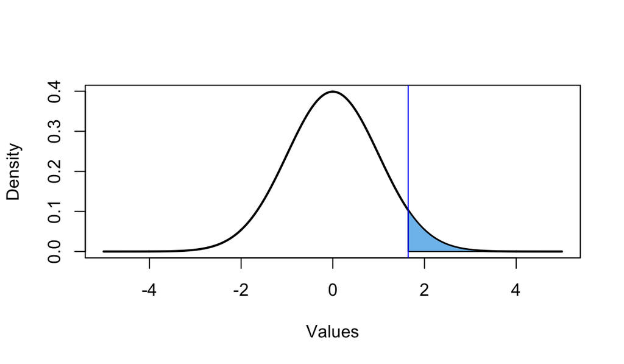

```r
PlotDist(alpha=0.05, distribution='normal', alternative='greater')
abline(v=cv, col='blue')
```

## Alternative Distribution

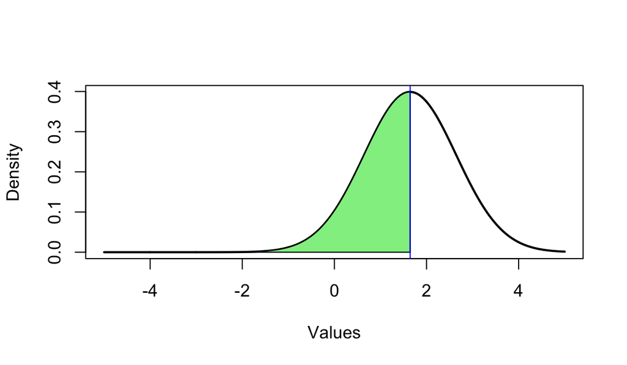

```r
cord.x1 <- c(-5, seq(from = -5, to = cv, length.out = 100), cv)
cord.y1 <- c(0, dnorm(mean=cv, x=seq(from=-5, to=cv, length.out = 100)), 0)
curve(dnorm(x, mean=cv), from = -5, to = 5, n = 1000, col = "black",
        lty = 1, lwd = 2, ylab = "Density", xlab = "Values")
polygon(x = cord.x1, y = cord.y1, col = 'lightgreen')
abline(v=cv, col='blue')
```

```r
pnorm(cv, mean=cv, lower.tail = FALSE)
```

```
## [1] 0.5
```

## Another Example (mu = 2.5)

```r
mu <- 2.5
(cv <- qnorm(0.05, mean=0, sd=1, lower.tail=FALSE))
```

```
## [1] 1.644854
```

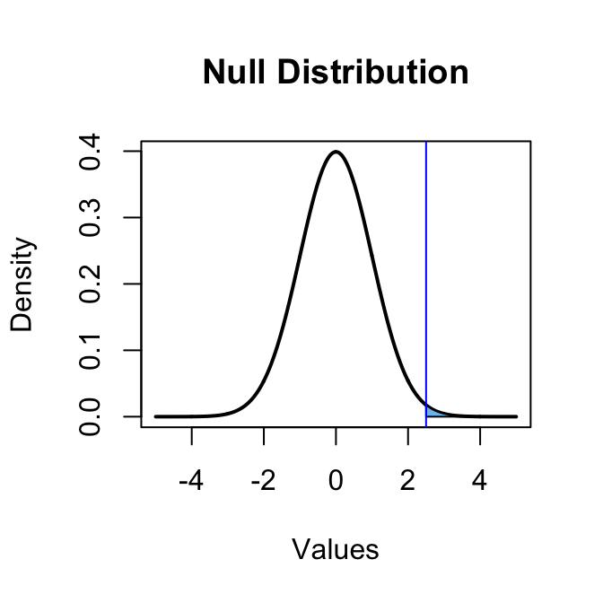

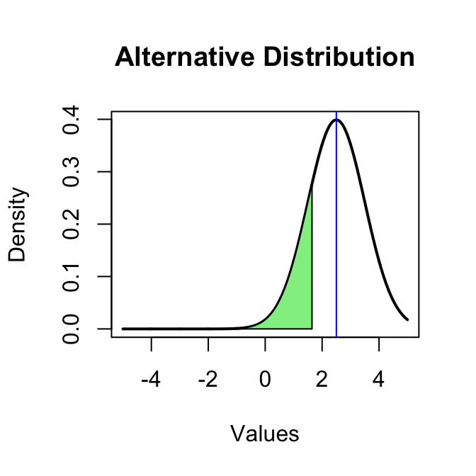

## Numeric Values

Type I Error

```r
pnorm(mu, mean=0, sd=1, lower.tail=FALSE)
```

```
## [1] 0.006209665
```

Type II Error

```r
pnorm(cv, mean=mu, lower.tail = TRUE)
```

```
## [1] 0.1962351
```

## Shiny Application

Visualizing Type I and Type II errors: http://shiny.albany.edu/stat/betaprob/

## Why p < 0.05?

Check out this page: https://www.openintro.org/stat/why05.php

See also:

Kelly M. [*Emily Dickinson and monkeys on the stair Or: What is the significance of the 5% significance level?*](http://www.acsu.buffalo.edu/~grant/5pcMarkKelley.pdf) Significance 10:5. 2013.

## Statistical vs. Practical Significance

- Real differences between the point estimate and null value are easier to detect with larger samples.
- However, very large samples will result in statistical significance even for tiny differences between the sample mean and the null value (effect size), even when the difference is not practically significant.
- This is especially important to research: if we conduct a study, we want to focus on finding meaningful results (we want observed differences to be real, but also large enough to matter).
- The role of a statistician is not just in the analysis of data, but also in planning and design of a study.